# hw6_Tianran

Tianran Zhang

7/7/2020

**1. Set your seed to 7 and run the following data generating function to simulate `n=10,000` COVID-19 patients.**

```r
set.seed(7)
generateData <- function(n){
  w1 <- rbinom(n, size=1, prob=0.35)
  w2 <- rnorm(n, mean = 6, sd = 1)
  w3 <- round(runif(n, min=0, max=4), digits=3)
  w4 <- round(runif(n, min=0, max=5), digits=3)
  A  <- rbinom(n, size=1, prob= plogis(-0.8 + 0.3*w2 + 0.25*w3 + 0.2*w4 + 0.3*w2*w4))
  # counterfactual
  Y_1 <- rbinom(n, size=1, prob= plogis(-3 + 1 -0.2*w1 + 0.35*w2 + 0.15*w3 + 0.25*w4 + 0.1*w2*w4))
  Y_0 <- rbinom(n, size=1, prob= plogis(-3 + 0 -0.2*w1 + 0.35*w2 + 0.15*w3 + 0.25*w4 + 0.1*w2*w4))
  # Observed outcome
  Y <- Y_1*A + Y_0*(1 - A)
  # return data.frame
  data.frame(w1, w2, w3, w4, A, Y, Y_1, Y_0)
}

n <- 10000
dat <- generateData(n)
```

**2. Calculate *and interpret* the true value of $\theta = E[Y_1]-E[Y_0]$.**

```r
theta <- mean(dat$Y_1) - mean(dat$Y_0)
```

The true value of $\theta = E[Y_1]-E[Y_0]$ is 0.118, which means that the expected death rate would change by 0.118 if contrary-to-fact all patients have steroids on first day of hypoxic state, compared to that if contrary-to-fact all patients do not have steroids on first day of hypoxic state.

# Simple TMLE Implementation

## Step 1: Estimate $m(A,W)$

$m(A,W) = logit[P(Y=1|A,W)]=β0+β1A+β_2^TW$

**3. Fit the above `glm` and use the `predict` function to obtain the outputs of $m(A,W)$, $m(1,W)$, and $m(0,W)$.**

```r
fit1 <- glm(Y ~ A + w1 + w2 + w3 + w4, family = "binomial", data = dat)

m_AW <- predict(fit1, newdata = dat, type = "response")
m_1W <- predict(fit1, newdata = data.frame(A = 1, w1 = dat$w1, w2 = dat$w2, w3 = dat$w3, w4 = dat$w4), type = "response")
m_0W <- predict(fit1, newdata = data.frame(A = 0, w1 = dat$w1, w2 = dat$w2, w3 = dat$w3, w4 = dat$w4), type = "response")
```

**4. If you were to stop here and estimate the casual parameter $\theta = E[Y_1]-E[Y_0]$ using $\hat{\theta} = \hat{m}(1,W)-\hat{m}(0,W)$, what statistical estimation technique would this be? Implement this estimation technique for comparison with TMLE.**

```r
theta.substitution <- mean(m_1W) - mean(m_0W)
```

$\hat{\theta} = \hat{m}(1,W)-\hat{m}(0,W)$ = 0.1334606 would be the statistical estimation technique of substitution estimator based on G-computation.  
Simple substitution estimators rely on the conditional mean outcome E[Y|A, W] and the covariate distribution P(W). Its consistency depends on consistent estimation of conditional mean outcome E[Y|A, W].  
TMLE require estimators of the conditional mean outcome E(Y |A, W), the exposure mechanism P(A|W), and the covariate distribution P(W). TMLE estimators are doubly robust estimator.

## Step 2: Estimate $g(W)$

$g(W) = logit[P(A=1|W)]=\alpha_0+\alpha_1^TW$

**5. Fit the above `glm` and use the `predict` function to obtain the outputs of $g(W)$. Compute $P(A=1|W)$ and $P(A=0|W)$ for every patient in the simulated study and call these vectors `prob_A1_given_W` and `prob_A0_given_W`.**

```r
fit2 <- glm(A ~ w1 + w2 + w3 + w4, family = "binomial", data= dat)
prob_A1_given_W <- predict(fit2, dat, type = "response")
prob_A0_given_W <- 1 - prob_A1_given_W
```

**6. Comment on the distributions of $\hat{g}(W)$ and $1-\hat{g}(W)$.**

```r
summary(prob_A1_given_W)
```

```
##    Min. 1st Qu.  Median    Mean 3rd Qu.    Max.
##  0.4409  0.9806  0.9978  0.9773  0.9998  1.0000
```

```r
summary(prob_A0_given_W)
```

```
##      Min.   1st Qu.    Median      Mean   3rd Qu.      Max.
## 0.0000054 0.0002320 0.0021730 0.0227000 0.0193712 0.5591381
```

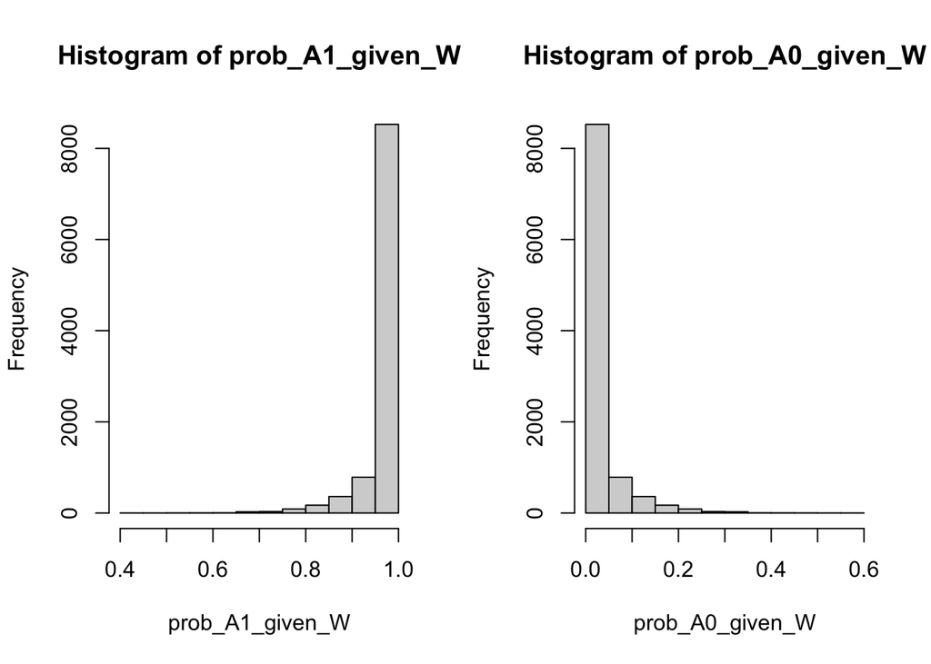

```r
par(mfrow = c(1, 2))
hist(prob_A1_given_W)
hist(prob_A0_given_W)
```

## Step 3: Estimate the clever covariate $H(A,W)$

**7. Use these estimates to create the clever covariate `H_AW`. Interpret the clever covariate for this particular background story.**

$$\hat{H}(A,W) = \left(\frac{\mathrm{I}(A=1)}{\hat{g}(W)} - \frac{\mathrm{I}(A=0)}{1-\hat{g}(W)} \right)$$

```r
prob_AW <- numeric(n)
prob_AW[dat$A == 1] <- prob_A1_given_W[dat$A == 1]
prob_AW[dat$A == 0] <- prob_A0_given_W[dat$A == 0]
H_AW <- dat$A/prob_A1_given_W - (1 - dat$A)/prob_A0_given_W
# H_AW <- 1/prob_AW
```

In this study, the clever covariate represents the inverse probability of receiving steroids on first day of hyoixic state minus the inverse probability of not receiving steroids on first day of hyoixic state for each patient, given that patient’s gender, age, SOFA pulmonary organ failure score, and number of relevant comorbidities. It has the same format with the weights used in IPW estimator. A patient would get a higher value of clever covariate if ths patient has a lower chance of receiving steroids on first day of hyoixic state given W.

**8. Also evaluate the clever covariate at $A=1$ and $A=0$ for all patients. Call the resulting vectors `H_1W` and `H_0W`, respectively.**

```r
H_1W <- 1/prob_A1_given_W
H_0W <- -1/prob_A0_given_W
```

The clever covariate at A = 1 for all patients represents the inverse probability of receiving steroids on first day of hyoixic state for each patient given that patient’s gender, age, SOFA pulmonary organ failure score, and number of relevant comorbidities.

The clever covariate at A = 0 for all patients represents the negative inverse probability of not receiving steroids on first day of hyoixic state for each patient given that patient’s gender, age, SOFA pulmonary organ failure score, and number of relevant comorbidities.

**9. What previously learned causal inference statistical estimation technique do you now have all the necessary information to complete? Implement this technique for comparison with TMLE.**

```r
wt <- 1/prob_AW
theta.ipw <- mean(dat$A * wt * dat$Y) -
  mean((1 - dat$A) * wt * dat$Y)
# theta.ipw


theta.aipw <- mean((H_AW * (dat$Y - m_AW)) + m_1W - m_0W)
# theta.aipw
```

Now I have all necessary information to complete IPTW estimator as well as Augmented IPW estimator. $IPTW = \frac{1}{n}\sum_{i = 1}^n\frac{I(A_i = a)}{P(A_i = a|W_i)}Y_i$. Here $\hat{\theta}_{ipw}$ = 0.466507. Standard IPTW estimator’s consistency depends on consistent estimation of the exposure mechanism P(A|W). However, TMLE require estimators of the conditional mean outcome E(Y |A, W), the exposure mechanism P(A|W), and the covariate distribution P(W). TMLE estimators are doubly robust estimator.  
$\hat{\theta}_{aipw} = \frac{1}{n}\sum_{i = 1}^n\{\frac{A_i}{\hat{g}(W_i)}[Y_i - \hat{m}(W_i)] + \hat{m}(W_i)\}$. We have $\hat{\theta}_{aipw}$ = 0.1138277. Augmented IPW and TMLE both use ML to solve model misspeciﬁcation bias, while still allowing computation of CIs and p-values.

## Step 4: Target the initial estimator

**10. Run a univariate regression of the outcome $Y$ on the clever covariate $\hat{H}(A,W)$ with the (logit of the) initial estimates as offset. Specifically, we estimate the coefficient $\epsilon$ by fitting the following logistic regression model:**
$$\begin{align*}
logit[m(A,W;\epsilon)] = logit[\hat{m}(A,W)] + \epsilon \hat{H}(A,W).
\end{align*}$$

```r
logit_update<- glm(dat$Y ~ -1 + offset(qlogis(m_AW)) + H_AW,
                  family='binomial')

summary(logit_update)
```

```
##
## Call:
## glm(formula = dat$Y ~ -1 + offset(qlogis(m_AW)) + H_AW, family = "binomial")
##
## Deviance Residuals:
##     Min       1Q   Median       3Q      Max
## -3.2066   0.1882   0.3231   0.5432   1.9363
##
## Coefficients:
##       Estimate Std. Error z value Pr(>|z|)
## H_AW -0.001034   0.002441  -0.424    0.672
##
## (Dispersion parameter for binomial family taken to be 1)
##
##     Null deviance: 6422.7  on 10000  degrees of freedom
## Residual deviance: 6422.5  on  9999  degrees of freedom
## AIC: 6424.5
##
## Number of Fisher Scoring iterations: 6
```

**11. Let `epsilon` denote the resulting maximum likelihood estimate of the coefficient on the clever covariate `H_AW`.**

```r
epsilon <- logit_update$coefficients
```

Here we estimated epsilon with a value of -0.0010343.

**12. Update the initial estimate of $\hat{m}(A,W)$ according to the fluctuation model:**

$$\begin{align*}
logit[\hat{m}(A,W)] &= logit [\hat{m}(A,W)] + \hat{\epsilon} \hat{H}(A,W) \\
\tilde{m}(A,W) &= expit \bigg[ logit\big[ \hat{m}(A,W) \big] + \hat{\epsilon} \hat{H}(A,W) \bigg]
\end{align*}$$

```r
m_AW_update <- plogis(qlogis(m_AW) + epsilon * H_AW)
```

**13. Plug-in the estimated coefficient $\hat{\epsilon}$ to yield targeted estimates of the expected outcome under the exposure $\tilde{m}(1,W)$ and under no exposure $\tilde{m}(0,W)$:**

$$\begin{align*}
\tilde{m}(1,W) &= expit \bigg[ logit\big[ \hat{m}(1,W) \big] + \hat{\epsilon} \hat{H}(1,W) \bigg]\\
\tilde{m}(0,W) &= expit \bigg[ logit\big[ \hat{m}(0,W) \big] + \hat{\epsilon} \hat{H}(0,W) \bigg]\\
\end{align*}$$

```r
m_1W_update <- plogis(qlogis(m_1W) + epsilon * H_1W)
m_0W_update <- plogis(qlogis(m_0W) + epsilon * H_0W)
```

**14. Estimate and interpret $\theta = E[Y_1]-E[Y_0]$ using TMLE. Compare it with the true value, and your estimates in the previous questions.**

```r
theta.tmle <- mean(m_1W_update) - mean(m_0W_update)
ans <- data.frame(estimates =c(theta, theta.tmle, theta.substitution, theta.aipw, theta.ipw))
ans$bias <- abs(theta - ans$estimates)
rownames(ans) <- c("theta.true", "theta.tmle", "theta.substitution",
                   "theta.AIPW", "theta.IPW")
ans
```

```
##                     estimates        bias
## theta.true         0.11800000 0.000000000
## theta.tmle         0.08620159 0.031798412
## theta.substitution 0.13346060 0.015460602
## theta.AIPW         0.11382771 0.004172295
## theta.IPW          0.46650698 0.348506984
```

# Inference

**15. How can we obtain standard errors for TMLE? How does this compare to G-Computation, IPTW, and Augmented IPTW?**  
Based on the asymptotic linearity of TMLE, we have the asymptotic variance $\sigma^2 = Var\{D_P(O)\}$. I compute Dp(Oi) for every subject: $D_P(O_i) = \frac{A_i}{\hat{g}(W_i)}[Y_i - \hat{m}(W_i)] + \hat{m}(W_i) - \hat{\theta}_{aipw}$, and then compute the empirical variance of Dp(Oi). $\hat{\theta}_{tmle} \sim N(0, \hat{\sigma}^2/n)$.  
I computed the standard error for Augmented IPW estimator with the same procedure: $D_P(O_i) = \frac{A_i}{\hat{g}(W_i)}[Y_i - \tilde{m}(W_i)] + \tilde{m}(W_i) - \hat{\theta}_{aipw}$, and then compute the empirical variance of Dp(Oi). $\hat{\theta}_{AIPW} \sim N(0, \hat{\sigma}^2/n)$

```r
# standard errors for TMLE:
se.tmle <- sqrt(var(H_AW* (dat$Y - m_AW_update) + (m_1W_update - m_0W_update) - theta.tmle)/n)
# standard errors for AIPW:
se.aiptw <- sqrt(var(H_AW * (dat$Y - m_AW) + (m_1W - m_0W) - theta.aipw)/n)

# standard errors for G-computation
# se.g <- sqrt(var(m_1W - m_0W)/n)
```

The standard error for TMLE is 0.0303042. The standard error for Augmented IPTW is 0.0336423. The standard errors for TMLE and Augmented IPTW are quite close to each other. However, we can not estimate the standard errors for G-computation and IPTW.

**16. What limitations do you see in estimating $g(W)$ and $m(A,W)$ using logistic regressions?**  
The estimation of $g(W)$ and $m(A,W)$ using logistic regressions strongly relys on the priori-specified regression model. Model misspecification would lead to unquantifiable bias.